# LbbC1

Ronny Raharjo

February 26, 2020

## 1. Library and Setup

Pada metode klasifikasi menggunakan Regresi Logistik dan K-NN ini, sebelumnya Anda harus melakukan install.package() pada package readr, tidyverse, MASS, gtools, gmodels, class, caret, ggplot2 pada R Studio Anda. Apabila telah ter-install, maka lakukan pengaktifan package menggunakan library().

```r
# libraries

library(readr)
library(tidyverse)
library(gtools)
library(gmodels)
library(class)
library(caret)
```

```r
library(ggplot2)
library(MASS)
```

R Markdown

## 2. Tujuan

Tujuan dari memprediksi data wholesale ini adalah untuk mendapatkan apakah channelnya berasal dari Horeca atau dari Retail. Metode yang digunakan dalam memprediksi ini adalah Logistic Regression dan KNN.

## 3. Logistic Regression

### 3.1 Data Import

Dataset mengacu pada klien dari distributor grosir. Ini termasuk pengeluaran tahunan dalam unit moneter (m.u.) pada kategori produk yang beragam.

Source: UCI Wholesale customers Data Set

```r
wholesale <- read.csv("data_input/wholesale.csv")
str(wholesale)
```

```
## 'data.frame':    440 obs. of  8 variables:
##  $ Channel         : int  2 2 2 1 2 2 2 2 1 2 ...
##  $ Region          : int  3 3 3 3 3 3 3 3 3 3 ...
##  $ Fresh           : int  12669 7057 6353 13265 22615 9413 12126 7579 5963 6006 ...
##  $ Milk            : int  9656 9810 8808 1196 5410 8259 3199 4956 3648 11093 ...
##  $ Grocery         : int  7561 9568 7684 4221 7198 5126 6975 9426 6192 18881 ...
##  $ Frozen          : int  214 1762 2405 6404 3915 666 480 1669 425 1159 ...
##  $ Detergents_Paper: int  2674 3293 3516 507 1777 1795 3140 3321 1716 7425 ...
##  $ Delicassen      : int  1338 1776 7844 1788 5185 1451 545 2566 750 2098 ...
```

Informasi penting dalam data :

Channel : (1 = Horeca; 2 = Retail)

Region : (1 = Lisnon; 2 = Oporto, 3 = Other)

Fresh : annual spending (m.u.) on fresh products

Milk : annual spending (m.u.) on milk products

Grocery : annual spending (m.u.)on grocery products

Frozen : annual spending (m.u.)on frozen products

Detergents_Paper : annual spending (m.u.) on detergents and paper products

Delicassen : annual spending (m.u.)on and delicatessen products

### 3.2 Data Manipulation

Memberikan label pada data kategorik yang merupakan data integer menjadi data faktor dan menghapus kolom Region karena nilainya hanya 3.

```r
wholesale_clean <- wholesale %>%

  mutate(Channel = factor(Channel, levels = c(1,2), labels = c("Horeca","Retail"))) %>%
  dplyr::select(.,-Region)
```

Lakukan pengecekan terhadap NA pada maisng-masing variabel.

```r
colSums(is.na(wholesale_clean))
```

```
##          Channel            Fresh             Milk          Grocery
##                0                0                0                0
##           Frozen Detergents_Paper       Delicassen
##                0                0                0
```

### 3.3 Exploratory Data Analysis

3.3.1 Modeling

Lakukan pengecekan proposional data antara Horeca dan Retail menggunakan prop.table() dan table. Jika data tidak proposional antara Horeca dan Retail misal Horeca 90% dan Retail 10% maka tidak perlu di buat model untuk memprediksinya, karena model apapun yang digunakan pasti semua mengacu ke Horeca.

```r
prop.table(table(wholesale_clean$Channel))
```

```
##
##    Horeca    Retail
## 0.6772727 0.3227273
```

```r
table(wholesale_clean$Channel)
```

```
##
## Horeca Retail
##    298    142
```

Membuat data training dan data testing.

```r
set.seed(303)
intrain<-sample(nrow(wholesale_clean),nrow(wholesale_clean)*0.7)
wholesale_clean_train<-wholesale_clean[intrain,]
wholesale_clean_test<-wholesale_clean[-intrain,]
wholesale_clean$Channel %>%
  levels()
```

```
## [1] "Horeca" "Retail"
```

```r
model<-glm(formula = Channel~Fresh+Milk+Grocery+Frozen, family = "binomial", data = wholesale_clean_train)
summary(model)
```

```
##
## Call:
## glm(formula = Channel ~ Fresh + Milk + Grocery + Frozen, family = "binomial",
##     data = wholesale_clean_train)
##
## Deviance Residuals:
##     Min       1Q   Median       3Q      Max
## -2.5480  -0.3713  -0.2311   0.0474   3.3305
##
## Coefficients:
##               Estimate Std. Error z value Pr(>|z|)
## (Intercept) -3.495e+00  4.376e-01  -7.989 1.37e-15 ***
## Fresh       -1.322e-05  1.625e-05  -0.814  0.41590
## Milk         6.802e-05  5.936e-05   1.146  0.25188
## Grocery      3.913e-04  6.163e-05   6.350 2.16e-10 ***
## Frozen      -2.562e-04  8.426e-05  -3.040  0.00236 **
## ---
## Signif. codes:  0 '***' 0.001 '**' 0.01 '*' 0.05 '.' 0.1 ' ' 1
##
## (Dispersion parameter for binomial family taken to be 1)
##
##     Null deviance: 373.89  on 307  degrees of freedom
## Residual deviance: 159.40  on 303  degrees of freedom
## AIC: 169.4
##
## Number of Fisher Scoring iterations: 7
```

Model fitting menggunakan metode stepwise.

```r
model2<-stepAIC(model,direction = "backward")
```

```
## Start:  AIC=169.4
## Channel ~ Fresh + Milk + Grocery + Frozen
##
##           Df Deviance    AIC
## - Fresh    1   160.06 168.06
## - Milk     1   160.68 168.68
## <none>         159.40 169.40
## - Frozen   1   174.15 182.15
## - Grocery  1   233.13 241.13
##
## Step:  AIC=168.06
## Channel ~ Milk + Grocery + Frozen
##
##           Df Deviance    AIC
## - Milk     1   161.18 167.18
## <none>         160.06 168.06
## - Frozen   1   182.42 188.42
## - Grocery  1   234.26 240.26
##
## Step:  AIC=167.18
## Channel ~ Grocery + Frozen
##
##           Df Deviance    AIC
## <none>         161.18 167.18
## - Frozen   1   183.80 187.80
## - Grocery  1   351.12 355.12
```

```r
summary(model2)
```

```
##
## Call:
## glm(formula = Channel ~ Grocery + Frozen, family = "binomial",
##     data = wholesale_clean_train)
##
## Deviance Residuals:
##     Min       1Q   Median       3Q      Max
## -2.8675  -0.3586  -0.2371   0.0383   3.2876
##
## Coefficients:
##               Estimate Std. Error z value Pr(>|z|)
## (Intercept) -3.537e+00  4.344e-01  -8.144 3.82e-16 ***
## Grocery      4.299e-04  5.216e-05   8.242  < 2e-16 ***
## Frozen      -2.631e-04  7.609e-05  -3.458 0.000543 ***
## ---
## Signif. codes:  0 '***' 0.001 '**' 0.01 '*' 0.05 '.' 0.1 ' ' 1
##
## (Dispersion parameter for binomial family taken to be 1)
##
##     Null deviance: 373.89  on 307  degrees of freedom
## Residual deviance: 161.18  on 305  degrees of freedom
## AIC: 167.18
##
## Number of Fisher Scoring iterations: 7
```

```r
wholesale_clean_test$prob_channel<-predict(model2, type = "response", newdata = wholesale_clean_test[,-7])
```

Melihat peluang sebarang prediksi data.

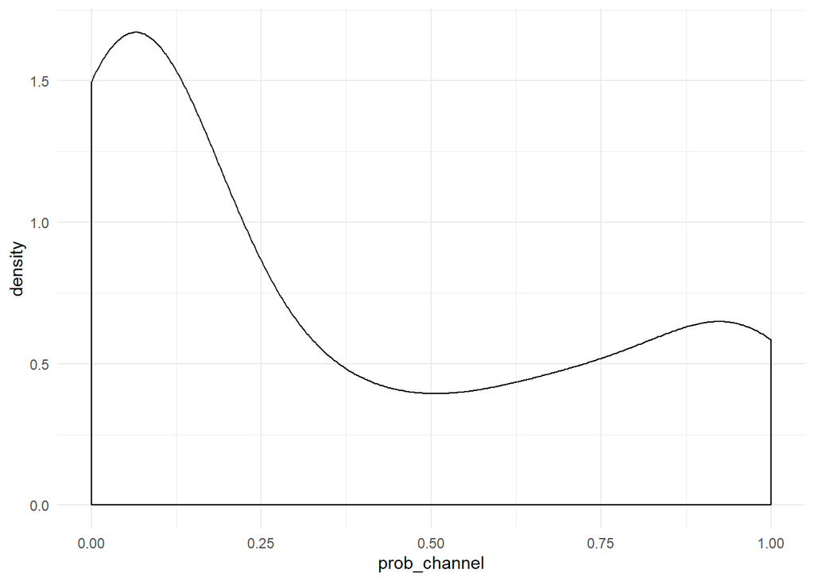

```r
ggplot(wholesale_clean_test, aes(x=prob_channel))+geom_density(lwd=0.5)+theme_minimal()
```

```r
wholesale_clean_test$pred_channel<-factor(ifelse(wholesale_clean_test$prob_channel>0.5, "Horeca","Retail"))
wholesale_clean_test[1:10,c("pred_channel","Channel")]
```

|  | pred_channel | Channel |
| --- | --- | --- |
| 2 | Horeca | Retail |
| 4 | Retail | Horeca |
| 6 | Retail | Retail |
| 7 | Retail | Retail |
| 12 | Retail | Retail |
| 17 | Horeca | Retail |
| 18 | Retail | Horeca |
| 19 | Horeca | Retail |
| 22 | Retail | Horeca |
| 26 | Retail | Retail |

3.3.2 Evaluation Model

```r
log_conf<-confusionMatrix(wholesale_clean_test$pred_channel, wholesale_clean_test$Channel, positive="Retail")
log_conf
```

```
## Confusion Matrix and Statistics
##
##           Reference
## Prediction Horeca Retail
##     Horeca      6     39
##     Retail     75     12
##
##                Accuracy : 0.1364
##                  95% CI : (0.0829, 0.2069)
##     No Information Rate : 0.6136
##     P-Value [Acc > NIR] : 1.000000
##
##                   Kappa : -0.6108
##
##  Mcnemar's Test P-Value : 0.001045
##
##             Sensitivity : 0.23529
##             Specificity : 0.07407
##          Pos Pred Value : 0.13793
##          Neg Pred Value : 0.13333
##              Prevalence : 0.38636
##          Detection Rate : 0.09091
##    Detection Prevalence : 0.65909
##       Balanced Accuracy : 0.15468
##
##        'Positive' Class : Retail
##
```

Re-call/Sensitivity = dari semua data aktual yang positif, seberapa mampu proporsi model saya menebak benar. Specificity = dari semua data aktual yang negatif, seberapa mampu proporsi model saya menebak yang benar. Accuracy = seberapa mampu model saya menebak dengan benar target Y.

```r
Recall = (12)/(39+12)
Specificity = (6)/(6+75)
Accuracy = (6+12)/(6+39+75+12)

paste("Recall", Recall)
```

```
## [1] "Recall 0.235294117647059"
```

```r
paste("Specificity", Specificity)
```

```
## [1] "Specificity 0.0740740740740741"
```

```r
paste("Accuracy", Accuracy)
```

```
## [1] "Accuracy 0.136363636363636"
```

## 4. K-Nearest Neighbour

Mengubah type data numeric menjadi scale

```r
ws_scale <-wholesale_clean %>%
  mutate_if(is.numeric,scale)
```

Membentuk data training dan data testing dari data ws_scale yang telah terbentuk.

```r
RNGkind(sample.kind = "Rounding")
set.seed(20)
index <- sample(nrow(ws_scale), nrow(ws_scale)*0.8)
train_x <- ws_scale[index, -1] # prediktor data train
test_x <- ws_scale[-index, -1] # prediktor data test
train_y <- ws_scale[index, 1] # target data train
test_y <- ws_scale[-index, 1] # target data test
```

Menghitung jumlah sqrt.

```r
sqrt(nrow(wholesale_clean))
```

```
## [1] 20.97618
```

Melakukan prediksi dengan K-NN

```r
pred_wholesale_knn <- knn(train = train_x, test = test_x, cl = train_y, k = 21)
```

Membuat confusion matriks dari prediski K-NN.

```r
pred_knn_conf <- confusionMatrix(pred_wholesale_knn, reference = test_y, positive = "Horeca")
```

## 5. Model Evaluation Logistic Regression and K-NN

```r
eval_logit <- data_frame(Accuracy = log_conf$overall[1],
           Recall = log_conf$byClass[1],
           Precision = log_conf$byClass[3])
eval_knn <- data_frame(Accuracy = pred_knn_conf$overall[1],
           Recall = pred_knn_conf$byClass[1],
           Precision = pred_knn_conf$byClass[3])
```

```r
eval_logit
```

| Accuracy | Recall | Precision |
| --- | --- | --- |
| 0.1363636 | 0.2352941 | 0.137931 |

```r
eval_knn
```

| Accuracy | Recall | Precision |
| --- | --- | --- |
| 0.9090909 | 0.9464286 | 0.9137931 |